# Seminar

26.04.2019

## Data Driven KPI (Key Performance Indicators) Insight & Prediction

**Case Studies: Deutsche Bahn AG**

[figure not shown]

## Einführung

Hintergrund:

- Deutsche Bahn hat Datenwachstum
- Die KPI (Key Performance Indicators) helfen Big Data in der einfachen Visualisierung besser zu verstehen

Ziel:

- Die Verwendung von KPI in Deutschen Bahn Konzern
- Kleines Datenanalyse Projekten zu zeigen, wie DB sein Problem mit datenanalyse lösen kann

Methode:

- Quantitative Ansätze
- Use Case

## Big Data Kernpunkte

- Big data muss 3V (Volume, Velocity, Variety) erfüllen:
  - Volume-> terabytes 1000 gigabytes
  - velocity-> terabytes or gigabytes / sekunden
  - Variety-> nicht nur csv or excel sondern audio (.wmap, .mp3), bildern (.jpg, .png), maschinen (.log) usw
- Basierend auf forbes.com haben nur 53% große Datenstrategien auf der ganzen Welt.
- Unternehmen mit big data strategien hat 3 mal deutliche Verbesserung gesteigert
- Die drei wichtigsten Anwendungsfälle sind Einzelhandel (data warehouse), Sozialanalyse (social media) und prädiktive Instandhaltung (predictive maintenance)

## KPI Nutzung

-> Bitte KPI Nutzung öffnen

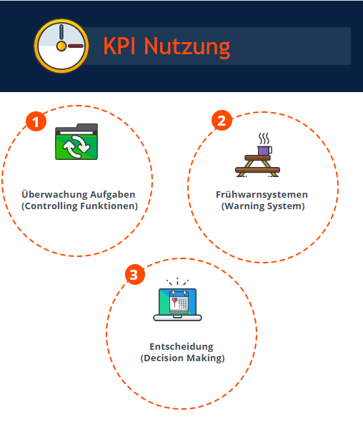

## Öffene Fragen

Danke für Ihre Aufmerksamtheit